# Graphic Devices in R

Mr. Sachin B.

### 1. What is Graphic Device?

A graphics device is something where you can make a plot appear

- A window on your computer (screen device)
- A PDF file (file device)
- A PNG or JPEG file (file device)
- A scalable vector graphics (SVG) file (file device)

When you make a plot in R, it has to be “sent” to a specific graphics device.

1. The most common place for a plot to be “sent” is the **screen device**
   1. Screen device on **Mac** is launched with the `quartz()`
   2. Screen device on **Windows** is launched with `windows()`
   3. Screen device on **Unix/Linux** is launched with `x11()`  
      Note: There is only one screen device on a Platform (Windows, Mac, Unix/Linux).
2. For plots that may be printed out or be incorporated into a document (e.g. Papers/Reports, Slide Presentation), a **file device** is useful.
   1. `pdf()`

### 2. How to create Plot

I. Creating plot on **screen device**.  
II. Creating plot on **file device**.

#### I. Creating plot on ‘screen device’

1. call a plotting Function
   - `plot()` in **base**, e.g. `plot(x,y)`,
   - `xyplot()` in **lattice**, or
   - `qplot()` in **ggplot2** will default to sending a plot to the screen device
2. Plot appears on the **screen device**
3. Annotate plot if necessary
   - `title(main= "Old Faithful Geyser data")`

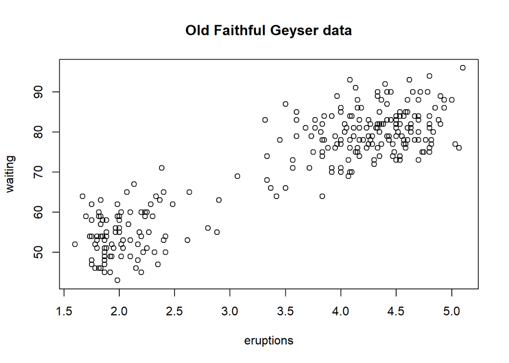

```r
library(datasets)

with(faithful,plot(eruptions,waiting)) ## Make plot appear on screen device
title(main= "Old Faithful Geyser data") ## Annotate plot
```

#### II. Creating plot on ‘file device’

1. Explicitly launch a graphics device
   - `pdf(file="myplot.pdf")`
2. call a plotting Function (**Note:if you are using a file device, no plot will appear on the screen** )
   - `plot()` in **base** e.g. `plot(x,y)`,
   - `xyplot()` in **lattice**, or
   - `qplot()` in **ggplot2**
3. Annotate plot if necessary
   - `title(main= "Old Faithful Geyser data")`
4. Explicitly close graphics device with `dev.off()` (**Note:This is very important step**)

```r
library(datasets)

pdf(file = "myplot.pdf") ## Open PDF file; create 'myplot.pdf' in working directory

with(faithful,plot(eruptions,waiting)) ## Create plot and send to a file (no plot appears on screen device)

title(main= "Old Faithful Geyser data") ## Annotate plot; still nothing on screen

dev.off() ## Close the PDF file device; Now the 'myplot.pdf' will appear on the screen.
```

### 3. Multiple Open Graphics Devices

It is possible to open multiple graphics devices (screen, file, or both).  
The **currently active graphics device** can be found by calling `dev.cur()`  
Every open graphics device is assigned an integer starting with 2 (there is no graphics device 1).  
You can change the active graphics device with `dev.set(<integer>)`

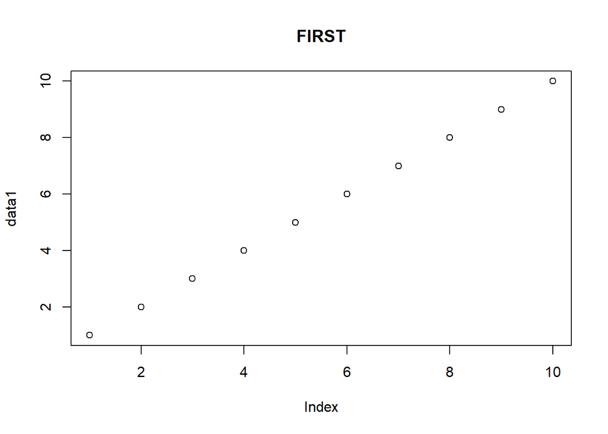

```r
# Open first device and plot data1
windows()
data1 <- 1:10
plot(data1,main="FIRST")
```

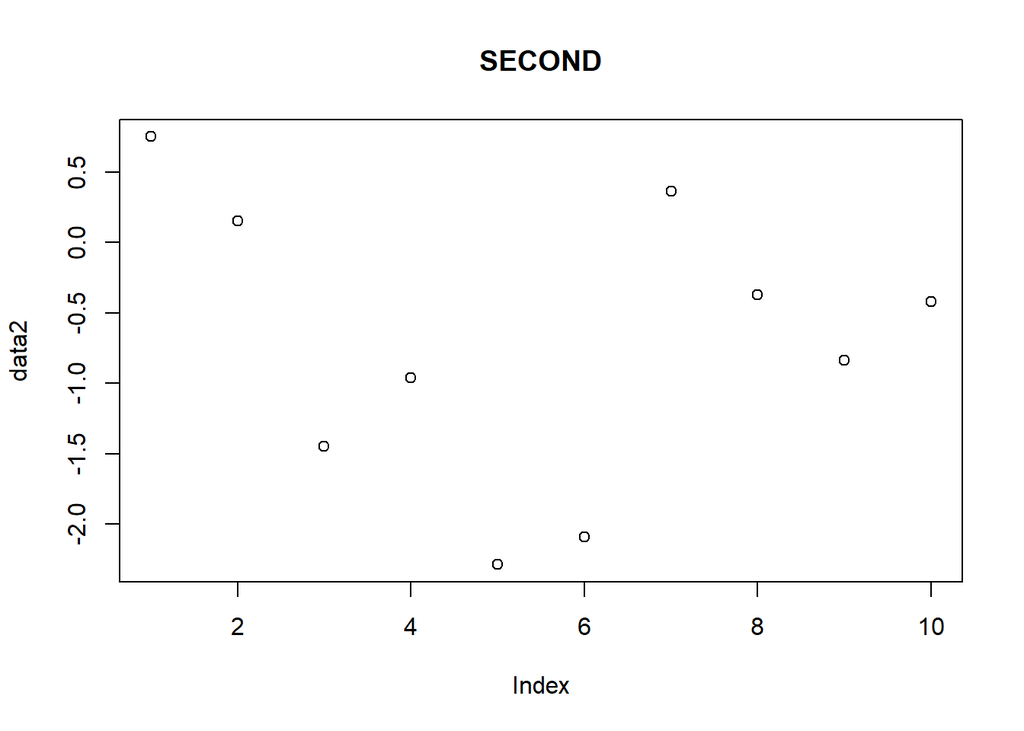

```r
# Open second device and plot data2
windows()
data2 <- rnorm(10)
plot(data2, main="SECOND")
```

```r
# 1. Currently active device `dev.cur()`
dev.cur()
```

```
## windows
##       4
```

```r
# 2. Setting active device `dev.set(<integer>)`

## set active device and draw line1
dev.set(3)
```

```
## windows
##       3
```

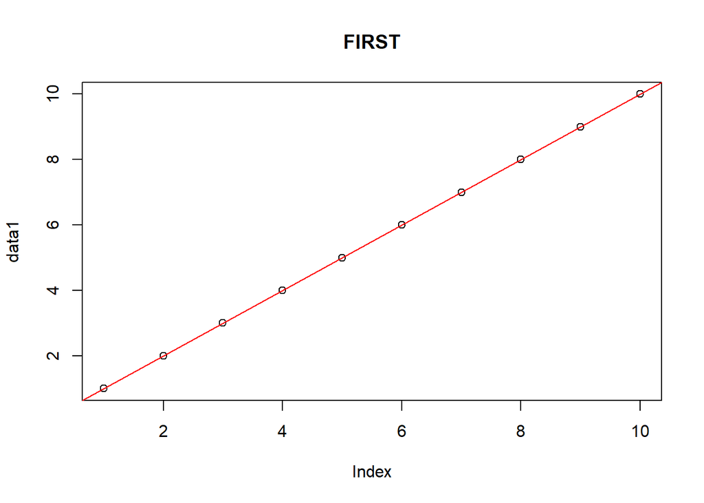

```r
abline(0,1, col = "red")
```

```r
# 3. Switching active device `dev.prev()` & `dev.next()`

## Switch active device and draw line2
dev.set(dev.next())
```

```
## windows
##       4
```

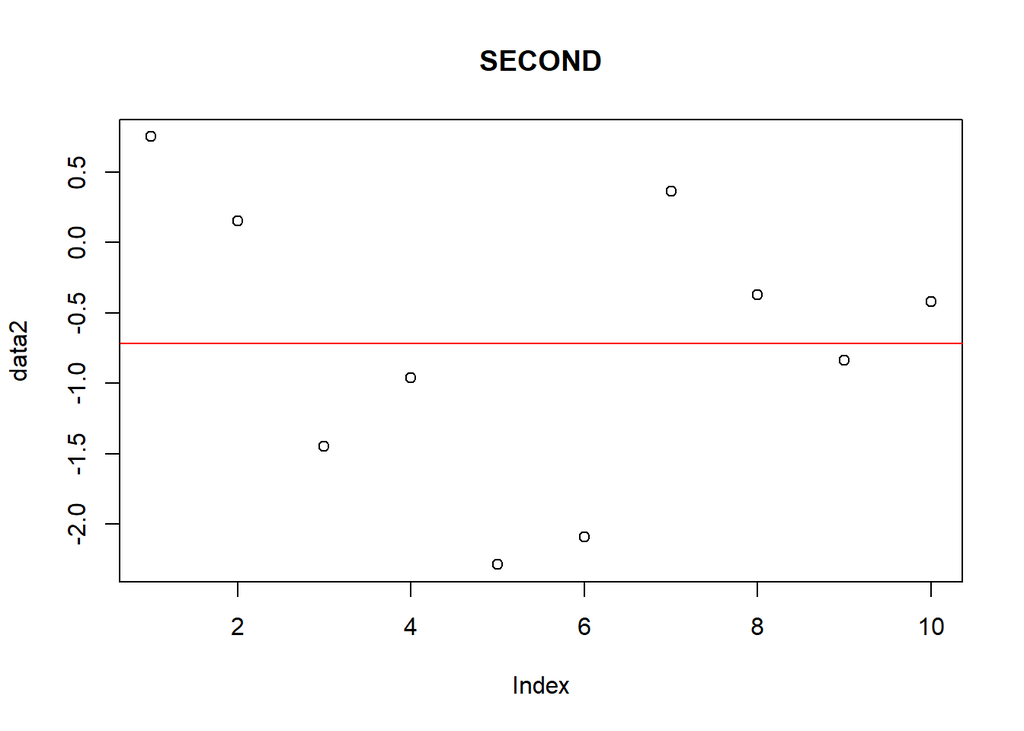

```r
abline(h = mean(data2), col = "red")
```

```r
## Switch active device and draw legend
dev.set(dev.prev())
```

```
## windows
##       3
```

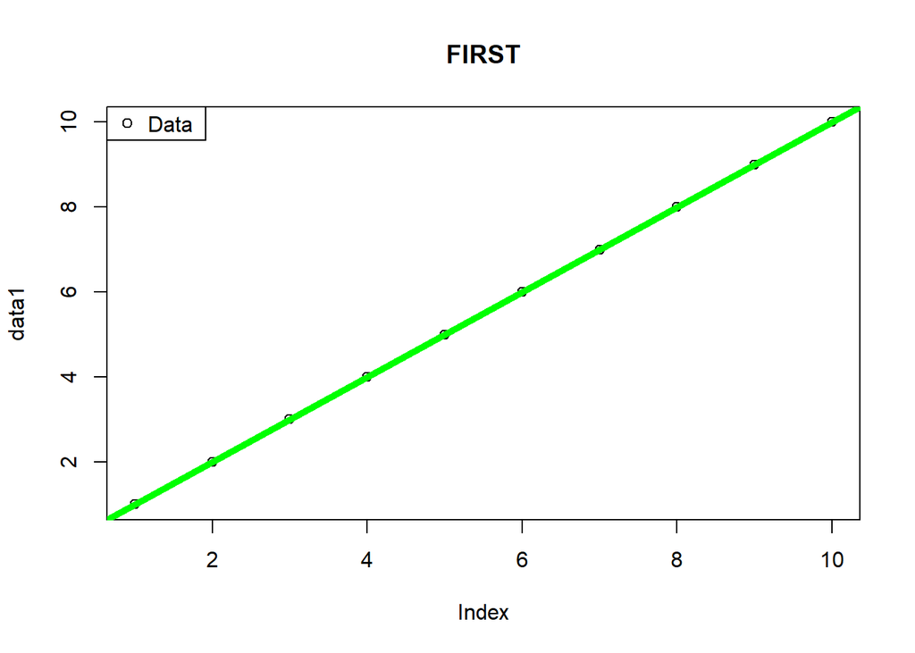

```r
abline(0,1, col = "green", lwd=5)
legend("topleft",legend = "Data", pch = 1)
```

### 4. Copying Plots

The `dev.copy()` can be used to copy a plot from one device to another.

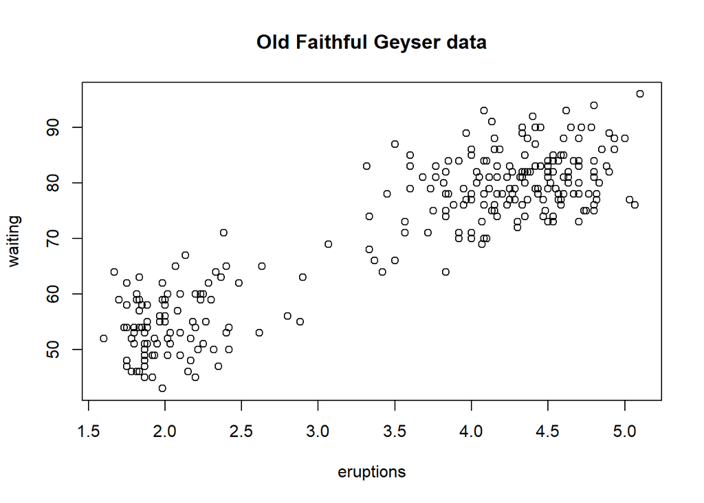

```r
library(datasets)

## Create plot on screen device
with(faithful, plot(eruptions, waiting))

## Add a main title
title(main = "Old Faithful Geyser data")
```

```r
## Copy my plot to a PNG file
dev.copy(png, file = "geyserplot.png")
```

```r
## Don't forget to close the PNG device!
dev.off()
```